# R Notebook

In Albion Online, the gold market is player-driven, meaning that item prices are determined by supply and demand. As a result, the price of items can fluctuate depending on the number of players selling and buying them. In addition, players can participate in trade and invest in the game’s economy, such as buying and selling land, buildings, or even entire cities.

I decided to investigate the changing price of gold in this game, gold enters the game when players buy it with real currency, later it is sold to players for in-game currency - silver, to buy various in-game privileges

```r
df <- read.csv('data/gold_data.csv')
df$date <- as.POSIXct(df$date, format="%Y-%m-%d")
head(df)
```

|  | price | date |
| --- | --- | --- |
| 1 | 649 | 2018-01-01 |
| 2 | 648 | 2018-01-01 |
| 3 | 649 | 2018-01-01 |
| 4 | 649 | 2018-01-01 |
| 5 | 650 | 2018-01-01 |
| 6 | 647 | 2018-01-01 |

```r
df %>%
  group_by(year=floor_date(date, "year")) %>%
  summarize(average_price=mean(price)) %>%
  mutate(annual_growth_rate=(average_price/lag(average_price) - 1) * 100)
```

| year | average_price | annual_growth_rate |
| --- | --- | --- |
| 2018-01-01 | 785.6057 | NA |
| 2019-01-01 | 2657.0287 | 238.214043 |
| 2020-01-01 | 2750.0645 | 3.501495 |
| 2021-01-01 | 2996.8669 | 8.974423 |
| 2022-01-01 | 3349.5780 | 11.769329 |

```r
NA
NA
```

The price spike occurred in 2018-2019 Consider the average price for the month:

```r
df %>%
  group_by(month=floor_date(date, "month")) %>%
  summarize(average_price=mean(price)) %>%
  mutate(month_growth_rate=(average_price/lag(average_price) - 1) * 100)
```

| month | average_price | month_growth_rate |
| --- | --- | --- |
| 2018-01-01 | 619.7089 | NA |
| 2018-02-01 | 666.8452 | 7.606207303 |
| 2018-03-01 | 698.5745 | 4.758118651 |
| 2018-04-01 | 716.9541 | 2.631011653 |
| 2018-05-01 | 751.9912 | 4.886939368 |
| 2018-06-01 | 926.0361 | 23.144538441 |
| 2018-07-01 | 1113.4470 | 20.237972287 |
| 2019-03-01 | 1698.0690 | 52.505588545 |
| 2019-04-01 | 1576.5823 | -7.154402413 |
| 2019-05-01 | 1737.1581 | 10.185058644 |

[output cut: 43 more lines]

```r
NA
```

We may notice that there is no data for the last 5 months in 2018

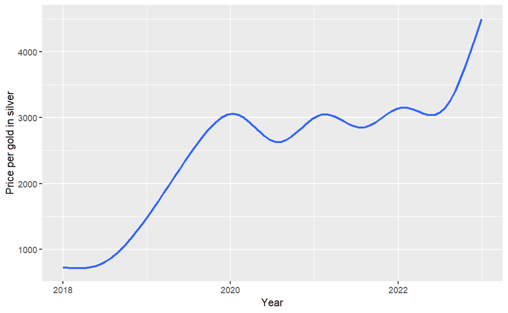

```r
ggplot(data=df)+
  geom_smooth(mapping=aes(x=date,y=price))+
  xlab("Year") + ylab('Price per gold in silver')
```

```r
NA
```

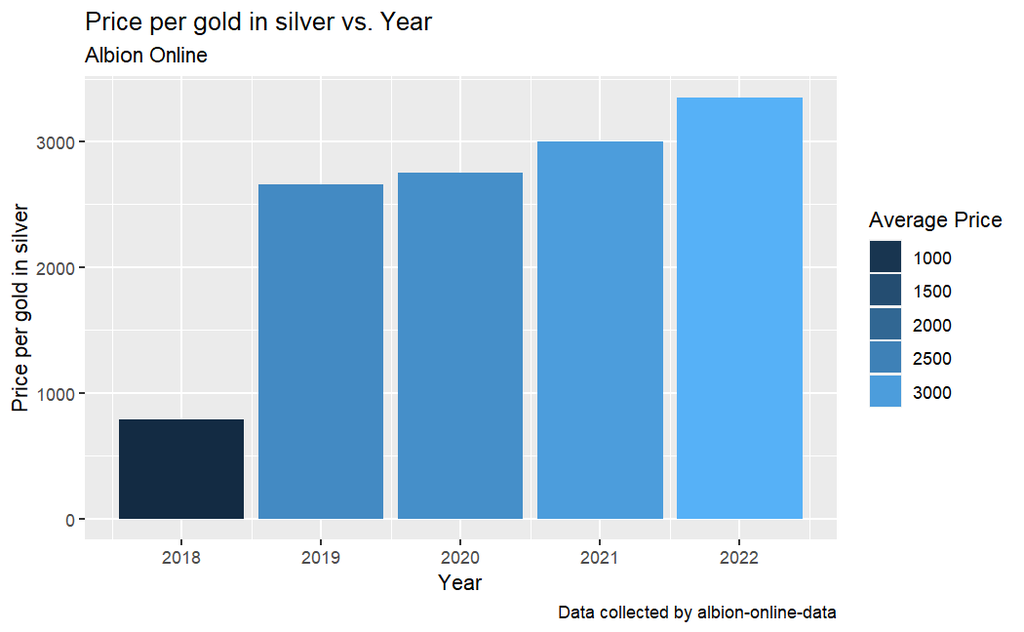

```r
df_bar <- df %>%
  group_by(year=floor_date(date, "year")) %>%
  summarize(average_price=mean(price)) %>%
  mutate(annual_growth_rate=(average_price/lag(average_price) - 1) * 100)
  ggplot(data=df_bar)+
    geom_col(mapping=aes(x=year,y=average_price,fill=average_price))+
    xlab("Year") + ylab('Price per gold in silver')+
    guides(fill=guide_legend(title="Average Price"))+
    labs(title="Price per gold in silver vs. Year", subtitle='Albion Online',
       caption="Data collected by albion-online-data")
```

As we can see from the visualization, the trend for gold demand continues Data Source: Albion Online Data